# Sesion 07 - Agregacion de Riesgos (Riesgo Colectivo)

Juan Carlos Martínez-Ovando

Otoño 2019

# 1 Objetivos

- Estudiaremos procedimientos generales para el calculo de la distribucion de riesgos agregados, $S_t$ bajo el enfoque de *riesgo colectivo*.
- Aplicaremos aproximaciones para el calculo de probabilidades en el extremo derecho de la distribucion de riesgos agregados, $\mathbb{P}(S_t > U)$.

# 2 Distribuciones compuestas

La distribucion de *riesgos agregados*, $F_{S_t}(s)$, depende de dos distribuciones:

- Distribucion primaria, sobre la *frecuencia de siniestros*, $F_{N_t}(n)$, y
- Distribucion secundaria, sobre la *severidad de siniestros individuales*, $F_X(x)$.

De esta forma, bajo el *supuesto de simetria estocastica y homogeneidad*, tenemos que la **distribucion de riesgos agregados** se calculara como
$$F_{S_t}(s)=\sum_{n} F^{*(n)}_X(s) f_n,$$
donde

- $F^{*(n)}_X(s)$ es la distribucion de la convolucion de $n$-terminos de $F_X(x)$,
- mientras que $f_n=\mathbb{P}(N_t=n)$.

> Recodemos que en caso, i.e. el modelo bajo el *enfoque de riesgo colectivo*, implicitamente el soporte de $F_X(x)$ es $(0,\infty)$ bajo *continuidad absoluta*.

> En este caso, se dice que la variable aleatoria $S_t$ es **compuesta**, i.e. la distribucion $F_{S_t}(s)$ es de **tipo compuesta**.

## 2.1 Momentos

En lo subsecuente, denotaremos el $k$-esimo momento de $X$ bajo $F_X(s)$ como
$$\mu^k = \mathbb{E}(X^k).$$

De esta forma, si estuviesemos interesados en calcular solo *momentos* de la distribucion de riesgos agregados, tendriamos:

$$\begin{eqnarray}
\mathbb{E}_{F_{S_t}}(S_t)
& = & \mathbb{E}_{F_{N_t}}\left(\mathbb{E}_{F_X}(S_t|N_t)\right) \nonumber \\
& = &\sum_n \mathbb{E}_{F_X}(X_1+\cdots,X_n|N_t = n) f_n \nonumber \\
& = &\sum_n \mathbb{E}_{F_X}(X_1+\cdots,X_n) f_n \nonumber \\
& = &\sum_n n \mu^1 f_n \nonumber \\
& = & \mu^1 \sum_n n f_n \nonumber \\
& = & \mu^1 \mathbb{E}_{F_{N_t}}(N_t). \nonumber
\end{eqnarray}$$

> Reflexionemos acerca de los supuestos que conducen al resultado anterior…

De manera analoga, la varianza de $S_t$ puede calcularse como
$$\begin{eqnarray}
var_{F_{S_t}}(S_t)
& = & \mathbb{E}_{F_{N_t}}\left(var_{F_X}(S_t|N_t)\right) + var_{F_{N_t}}\left(\mathbb{E}_{F_X}(S_t|N_t)\right) \nonumber \\
& = & \mathbb{E}_{F_{N_t}}\left(N_t var(X)\right) + var\left(N_t \mu^1\right) \nonumber \\
& = & \mathbb{E}_{F_{N_t}}(N_t)var_{F_X}{X} + \mu^1 var_{F_{N_t}}(N_t).
\end{eqnarray}$$

> Cuando $N_t$ tenga asociada una distribucion Poisson, tendremos que el resultado anterior se simplifica a
> $$var_{F_{S_t}}(S_t) = \mathbb{E}_{F_{N_t}}(N_t) \mu^2.$$

## 2.2 Ejercicio 1

Empleen el procedimiento analogo al anterior para obtener la funcion generadora de momentos de $F_{S_t}(s)$. El resultado a obtener es
$$M_{S_t}(w)=M_{N_t}\left(\log M_X(w)\right),$$
siendo $M_X(w)$ y $M_{N_t}(w)$ las funciones generadoras de momentos marginales para $X$ y $N_t$, respectivamente.

## 2.3 Ejemplo 1

Aplicando el resultado del **ejercicio a entregar**, podemos obtener analiticamente la distribucion de riesgos agregados del modelo en el que:

1. La distribucion primaria es $\operatorname{\text{Geo}}(N_t|\theta)$,
2. La distribucion secundaria es $\operatorname{\text{Exp}}(X|\lambda=1)$.

Recordando que
$$\begin{eqnarray}
M_{N_t}(w) & = & \frac{\theta}{1-(1-\theta)e^w}, \nonumber \\
M_{X}(w) & = & \left(1-w\right)^{-1}, \nonumber \\
\end{eqnarray}$$
tenemos que
$$M_{S_t}(w) = \theta + (1-\theta)\frac{\theta}{\theta-w}.$$
> ?`Que distribucion es la asociada a $M_{S_t}(w)$?

## 2.4 Ejercicio 2

Encuentren la distribucion asociada con el modelo compuesto donde:

1. La distribucion primaria es $\operatorname{\text{Geo}}(N_t|\theta)$ modificada en $0$,
2. La distribucion secundaria es $\operatorname{\text{Exp}}(X|\lambda=1)$.

## 2.5 Caso severidades discretizadas

En ocasiones, la distribucion de *severidades individuales*, $F_X(x)$, puede ser discretizada, con soporte en
$$\mathcal{X}^d=\{x^*_1,\dots,x^*_D\},$$
(siendo $D$ posiblemente infinito), con masas de probabilidades
$$\pi_k = \mathbb{P}(X=x^*_k).$$
En este caso, los riesgos agregados $S_t$ seran definidos como la suma de los riesgos particulares para cada valor $x^*_k$ particular, i.e.
$$\begin{eqnarray}
S_t
& = & \sum_{j=0}^{N_t} X_{tj} \nonumber \\
& = & x*_1 N_{t1} + x^*_2 N_{t2} + \cdots + x^*_D N_{tD}, \nonumber
\end{eqnarray}$$
donde $N_{tk}$ es el numero (aleatorio/desconocido) de riesgos que tuvieron una siniestralidad igual a $X^*_k$.

Se debe satisfacer la relacion composicional,
$$N_t = N_{t1} + \cdots + N_{tD}.$$

> Se sigue que si $N_t$ sigue una distribucion Poisson con tasa de intensidad $\lambda_t$, entonces cada $N_{tk}$ sigue una distribucion Poisson tambien con tasa de intensidad dada por
> $$\lambda_{tk}=\pi_k \lambda_t,$$
> para todo $k$.

> Esta propiedad de desagregacion es muy impotante para el proceso de diversificacion de riesgos via mezclas.

## 2.6 Ejemplo 2

En este ejemplo, veremos como realizar el calculo exacto de la *distribucion de riesgos agregados* $S_t$ cuando:

1. $X$ es una variable aleatoria discretizada no negativa, y
2. $N_t \sim \operatorname{\text{Po}}(n|\lambda)$.

El calculo exacto se obtiene empleando el script `IntVal.Poisson.R` que se encuentra en la subcarpeta [Scripts].

Las masas de probabilidad y soporte de $F_{S_t}(s)$ generado para este ejemplo particular se calcula de la siguiente forma:

```r
source("./Scripts/IntVal.Poisson.R")

f_S <- IntVal.Poisson(c(1,2,3,4))
f_S
```

```
##   [1]  4.539993e-05  4.539993e-05  1.134998e-04  2.345663e-04  4.558910e-04
##   [6]  6.284107e-04  1.063178e-03  1.633271e-03  2.354492e-03  3.167861e-03
##  [11]  4.429612e-03  5.856712e-03  7.479815e-03  9.342996e-03  1.163189e-02
##  [16]  1.400197e-02  1.651835e-02  1.921772e-02  2.207884e-02  2.482349e-02
##  [21]  2.751959e-02  3.014317e-02  3.258611e-02  3.469613e-02  3.652677e-02
##  [26]  3.803508e-02  3.914558e-02  3.982093e-02  4.011241e-02  4.000923e-02
##  [31]  3.950588e-02  3.863514e-02  3.745438e-02  3.599077e-02  3.428290e-02
##  [36]  3.238565e-02  3.035290e-02  2.822416e-02  2.604297e-02  2.385349e-02
##  [41]  2.169223e-02  1.958731e-02  1.756489e-02  1.564651e-02  1.384699e-02
##  [46]  1.217586e-02  1.063958e-02  9.240641e-03  7.977782e-03  6.847151e-03
##  [51]  5.843146e-03  4.958471e-03  4.184614e-03  3.512476e-03  2.932732e-03
##  [56]  2.435995e-03  2.013090e-03  1.655285e-03  1.354402e-03  1.102869e-03
##  [61]  8.937914e-04  7.209746e-04  5.789095e-04  4.627434e-04  3.682471e-04
##  [66]  2.917692e-04  2.301818e-04  1.808265e-04  1.414622e-04  1.102132e-04
##  [71]  8.552014e-05  6.609517e-05  5.088181e-05  3.901857e-05  2.980709e-05
```

[output cut: 94 more lines]

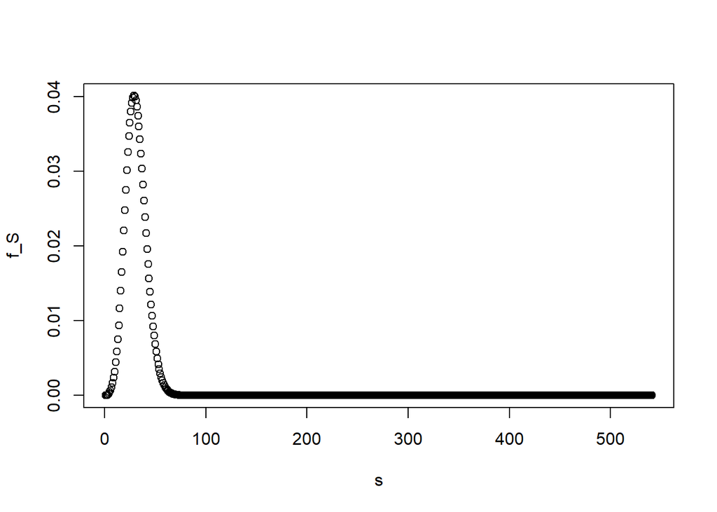

```r
plot(f_S,xlab="s")
```

> Revisen el codigo del script `IntVal.Poisson.R`.

## 2.7 Ejemplo 3

El calculo explicito involucrado en el script `IntVal.Poisson.R` puede ser particularmente costoso, desde un punto de vista computacional. Por esta razon, Panjer diseno un algoritmo computacional mas eficiente para el calculo de $F_S(s)$ conocido como el **algoritmo de recursion de Panjer**.

- El algoritmo de recursion de Panjer descansa en el supuesto que:
1. $F_{N_t}(n)$ pertenece a la clase $(a,b,0)$ –o a la clase $(a,b,1)$–,
2. El soporte de $X$ es discretizado en $\mathcal{X}=\{0,1,2,3\ldots,D\}$, siendo $D$ potencialmente infinito.

De esta forma, respecto a la frecuencia de siniestros, tenemos
$$f_n = \left(a+\frac{b}{n}\right)f_{n-1},$$
para $n=1,2,\ldots$, con $f_0$ dado.

De esta forma, se cumplen las siguientes relaciones:

$$f^S_0 = \mathbb{P}(S_t=0)
\begin{cases}
\mathbb{P}(N_t=0), & \text{ si } \pi_0=0,\\
M_{N_t}(\log \pi_0),& \text{ si } \pi_0 > 0.
\end{cases}$$
Y, para todos los valores en el soporte $\mathcal{S}$ distintos de $0$, se cumple
$$f^S_s = \frac{1}{1-a\pi_0}\sum_{h=1}^{s}\left(a + \frac{bh}{s}\right)\pi_h f_{s-h}.$$
La implementcion de esta recursion la pueden encontrar en el codigo `Panjer.Poisson.R` para el caso $N_t$ distribuido Poisson dentro de la subcarpeta [Scripts].

En el ejemplo, las masas de probabilidad $\pi_k$ estan dadas por el vector `c(.1,0.2,0.3,0.4)`, mientras que la tasa de intensidad de la distribucion Poisson es $\lambda=4$.

```r
source("./Scripts/Panjer.Poisson.R")

f_S <- Panjer.Poisson(c(.1,0.2,0.3,0.4), 4) * exp(4)
f_S
```

```
##  [1] 1.000000e+00 4.000000e-01 8.800000e-01 1.530667e+00 2.465067e+00
##  [6] 1.832619e+00 2.636592e+00 3.236762e+00 3.485888e+00 3.088185e+00
## [11] 3.533923e+00 3.601740e+00 3.376844e+00 3.046156e+00 3.014627e+00
## [16] 2.752498e+00 2.406398e+00 2.100860e+00 1.882955e+00 1.599662e+00
## [21] 1.330832e+00 1.110282e+00 9.265063e-01 7.467776e-01 5.956442e-01
## [26] 4.749733e-01 3.754254e-01 2.901416e-01 2.228130e-01 1.705073e-01
## [31] 1.290645e-01 9.624099e-02 7.140091e-02 5.267955e-02 3.846452e-02
## [36] 2.779025e-02 1.997976e-02 1.427237e-02 1.010248e-02 7.093885e-03
## [41] 4.956314e-03 3.440118e-03 2.369049e-03 1.620823e-03 1.103265e-03
## [46] 7.462212e-04 5.013171e-04 3.348830e-04 2.225698e-04 1.470489e-04
## [51] 9.657879e-05 6.310613e-05 4.103060e-05 2.653168e-05 1.706570e-05
## [56] 1.092484e-05 6.960446e-06 4.412337e-06 2.783648e-06 1.748302e-06
## [61] 1.093074e-06 6.802394e-07 4.214556e-07 2.600184e-07
```

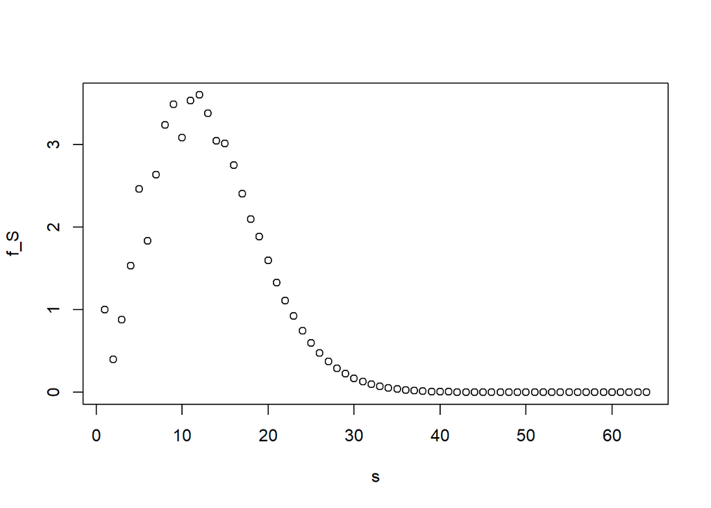

```r
plot(f_S,xlab="s")
```

> Revisen el codigo del script `Panjer.Poisson.R`.

# 3 Probabilidades en extremo derecho

> Como hemos mencionado antes, es de suma importancia modelar la distribucion de *riesgos agregados* de manera que la probabilidad
> $$\mathbb{P}(S_t >U),$$
> sea **eficente** y **prudencialmente** calculada.

De esta forma, en esta parte de la sesion exploraremos la forma de calcular la probabilidad en extremos en el caso de riesgos agregados,
$$S_t = \sum_{j=1}^{N_t} X_{tj},$$
donde
$$N_t \sim \operatorname{\text{Po}}(n|\lambda_t),$$
y
$$X_{tj} \sim^{iid} F_X(x).$$
considerando que
$$N_t \text{ y } (X_{tj})_{j\geq 1},$$
sean *independientes estocasticamente* (i.e. *mutuamente separables*).

Es decir, estamos intereados en calcular la distribucion
$$F_{S_t}(s) = \mathbb{P}(S_t \leq s),$$
y, a partir de ella, calcular
$$\mathbb{P}(S_t > U),$$
para un valor de $U$ grande, o calcular $U_\alpha$ tal que
$$\mathbb{P}(S_t > U_{\alpha}) \leq \left(1-\alpha\right),$$
para valores de
$$\alpha \approx 1.$$

## 3.1 Ejemplo 4

Ilustraremos, en particular, el calculo de estas probabilidades considerando el caso en que
$$F_X(x) = \operatorname{\text{logN}}(x|\mu, \sigma^2).$$

Consideraremos ademas, para esta practica, el uso de datos simulados con los siguientes parametros:

con los umbrales dados por los parametros

```r
lambda <- 50
mu <- 5
sigma2 <- 1
q <- 20000
alpha <- 0.99
```

Recordemos que respecto a la distribucion $\operatorname{\text{Po}}(n|\lambda)$, el parametro $\lambda$ representa la intensidad de la distribucion, caracterizando el primero y segundo momentos de la misma.

Respecto a la distribucion log-normal, $logNormD(x|\mu,\sigma^2)$, recordemos que los parametros caracterizan los siguientes momentos:
$$\begin{eqnarray}
\matbb{E}(X|\mu,\sigma^2) & = & \exp\left\{\mu + (\sigma^2)/2\right\},\nonumber \\
var(X|\mu,\sigma^2) = \left(\exp\{\sigma^2\}-1\right) \exp\left\{2*\mu + \sigma^2\}.\nonumber
\end{eqnarray}$$

De esta forma, los primeros tres momentos de la distribucion $F_{S_t}(s)$ son:

1. Media

$$\mathbb{E}(S_t|\lambda,\mu.\sigma^2) = \lambda \ \mu^1_{X},$$

2. Varianza

3. Sesgo

El calculo de los momentos de la distribucion log-normal se obtienen con el cordigo `logNormal.moment.R` contenido en la subcarpeta [Scripts] (revisenlo, es muy sencillo).

De esta forma, los primeros tres momentos de la distribucion $F_{S_t}(s)$ referidos a:

1. Media
2. Varianza
3. Sesgo,

se obtienen analiticamente como:

```r
source("./Scripts/logNormal.moment.R")
E.S <- lambda * logNormal.moment(1, mu = mu, sig = sigma2)
E.S
```

```
## [1] 12234.6
```

```r
var.S <- lambda * logNormal.moment(2, mu = mu, sig = sigma2)
var.S
```

```
## [1] 8137740
```

```r
skew.S <- logNormal.moment(3, mu = mu, sig = sigma2) /
    sqrt(lambda * (logNormal.moment(2, mu = mu, sig = sigma2))^3) # skew(S)
skew.S
```

```
## [1] 0.6338065
```

> Aunque estos tres parametros no estan relacionados directamente con el calculo de las probabilidades en el extremo derecho de la distribucion $F_{S_t}(s)$, pueden ser empleados para aproximar tales probabilidades empleando *aproximaciones asintoticas*. En particular, consideraremos dos de ellas.

## 3.2 Aproximacion normal

Asi, podemos aproximar tres caracteristicas en el extremo derecho de la distribucion:

1. $\mathbb{P}(S_t > U)$
2. $\text{VaR}_\alpha(S_t)$
3. $\text{ES}_\alpha(S_t)$.

Estas probabilidades estan en el orden:

```r
tprob.N <- pnorm(q, mean = E.S, sd = sqrt(var.S), lower.tail = FALSE)
tprob.N
```

```
## [1] 0.00324293
```

```r
VaR.N <- E.S + sqrt(var.S) * qnorm(alpha)
VaR.N
```

```
## [1] 18870.9
```

```r
ES.N <- E.S + sqrt(var.S) * dnorm(qnorm(alpha)) / (1-alpha)
ES.N
```

```
## [1] 19837.58
```

## 3.3 Aproximacion con gamma trasladada

Las mismas caracteristicas las aproximaremos empleando la distribucion asintotica gamma trasladada que vimos en clase previamente.

Recordemos que la distribucion gamma trasladada en $k$ se obtiene como
$$S_t = k + G,$$
donde
$$G \sim \operatorname{\text{Ga}}(g|a, b).$$

De esta forma, sabemos que:

- $\mathbb{E}_{\operatorname{\text{Ga}}}(S_t) = k + \frac{a}{b}$,
- $var_{\operatorname{\text{Ga}}}(S_t) = \frac{a}{b^2}$,
- $skew_{\operatorname{\text{Ga}}}(S_t) = \frac{2}{\sqrt{a}}$.

De esta forma, empatando los momentos bajo la distribucion $F_S(s)$ con los de la distribucion $\operatorname{\text{Ga}}(s|k,a,b)$, encontramos la siguientes relaciones:

- $\hat{a} = \left(\frac{2}{skew(S_t)}\right)^2$
- $\hat{b} = \sqrt{\frac{\hat{a}}{var(S_t)}}$
- $\hat{k} = \mathbb{E}(S_t) - \frac{\hat{a}}{\hat{b}}$.

Los calculos pueden obtenerse en `R` de manera sencilla como se muestra a continuacion:

```r
shape <- (2/skew.S)^2
shape
```

```
## [1] 9.957414
```

```r
rate <- sqrt(shape/var.S)
rate
```

```
## [1] 0.001106169
```

```r
k <- E.S - shape/rate
k
```

```
## [1] 3232.883
```

Una vez identificados estos parametros, podemos calcular las caracteristicas en el extremo derecho de la distribucion, entendiendo que:

1. Probabilidad,
   $$\begin{eqnarray}
   \bar{F}_S(U)
   & = & P(S > U) \nonumber \\
   & = & \mathbb{P}(S-k > U-k) \nonumber \\
   & = & \mathbb{P}(G > U-k) \nonumber \\
   & = & \bar{F}_G(U-k).\nonumber
   \end{eqnarray}$$
2. Valor en riesgo,
   $$\begin{eqnarray}
   \text{VaR}_{\alpha}(S_t)
   & = & F^{-1}_S(\alpha) \nonumber \\
   & = & k + F_G^{-1}(\alpha).\nonumber
   \end{eqnarray}$$
3. *Expected shortfall*
   $$\begin{eqnarray}
   \text{ES}_\alpha(S_t)
   & = & \left(\frac{1}{1-\alpha}\right) \int_\alpha^1 \text{VaR}_u(S_t) \text{d}u \nonumber \\
   & = & k + \left(\frac{1}{1-\alpha}\right) \int_\alpha^1 F_G^{-1}(u) \text{d}u \nonumber \\
   & = & k + \left(\frac{1}{1-\alpha}\right) \int_{F_G^{-1}(\alpha)}^\text{inf} x \ f_G(x) \text{d}x. \nonumber
   \end{eqnarray}$$

Los calculos, bajo esta aproximacion, resultan en:

```r
tprob.tg <- pgamma(q-k, shape = shape, rate = rate, lower.tail = FALSE)
tprob.tg
```

```
## [1] 0.01103915
```

```r
VaR.tg <- k + qgamma(alpha, shape = shape, rate = rate)
VaR.tg
```

```
## [1] 20160.44
```

```r
ES.tg <- k + ((shape/rate) / (1-alpha)) *
     pgamma(qgamma(alpha, shape = shape, rate = rate),
            shape = shape + 1, rate = rate, lower.tail = FALSE)
ES.tg
```

```
## [1] 21695.67
```

## 3.4 Aproximacion via recursion de Panjer

Consideremos ahora que discretizamos la distribucion log-normal de manera que las $X_{tj}$’s tengan soporte en
$$\mathcal{X}^d = \{0,1,2,...\}$$
con
$$\pi_k = \mathbb(X_j = k).$$

De manera complementaria, $N_t$ tendra un soporte discreto en
$$\mathcal{N} = \{0,1,2,...\},$$
con
$$f_n = \mathbb{P}(N_t = n)$$
definidos dentro de la clase $(a,b,0)$ adecuada.

Aplicando, en primer lugar la **discretizacion de** $F_X(x)$ tenemos:

```r
nsteps <- 50000
stopifnot(nsteps + 1 >= floor(q))

pts <- c(0, 1:(nsteps+1)- 0.5) # x**_k
f <- diff(plnorm(pts, meanlog = mu, sdlog = sigma2)) # length = nsteps + 1
```

Aplicando ahora la **recursion de Panjer**, obtenemos las masas de probabilidad para $F_{S_t}(s)$:

```r
a <- 0
b <- lambda
s <- numeric(nsteps+1)
s[1] <- exp(lambda * (f[1] - 1))
fct <- 1 - f[1] * a
for(k in 1:nsteps) {
    j <- 1:k
    s[k+1] <- fct * sum((a + b*j/k) * f[j+1] * s[k-j+1])
}
```

A partir de estas masas de probabilidades, calculamos las caracteristicas en el extremo derecho de la *distribucion de riesgs agregados*:

```r
S.df <- cumsum(s)

tprob.pr <- 1 - S.df[floor(q)]
tprob.pr
```

```
## [1] 0.01080443
```

```r
ii <- which(S.df >= alpha)
stopifnot(length(ii) > 0)
VaR.pr <- min(ii)
VaR.pr
```

```
## [1] 20134
```

```r
ES.pr <- sum((ii-1) * s[ii]) / (1-alpha)
ES.pr
```

```
## [1] 21942.06
```

## 3.5 Comparacion

Calculando las aproximaciones de $\mathbb{P}(S_t > U)$, tenemos

[output not shown]

Calculando las aproximaciones de $\text{VaR}_\alpha(S_t)$, tenemos

[output not shown]

Calculando las aproximaciones de $\text{ES}_\alpha(S_t)$, tenemos

[output not shown]

# 4 Comentarios

- En la siguiente sesion compararemos los calculos anteriores con los que se obtendrian via simulacion estocastica.
- Revisen el codigo/scripts y aproximaciones asintoticas.